# (Communicate Data Finding : Ford GoBike System Data)

## by (Eng.Mohamed Mostafa)

## Preliminary Wrangling

> bicycle sharing system in California's San Francisco Bay Area. It is operated by Motivate in a partnership with the Metropolitan Transportation Commission and the Bay Area Air Quality Management District. Bay Wheels is the first regional and large-scale bicycle sharing system deployed in California and on the West Coast of the United States. It was established as Bay Area Bike Share in August 2013. As of January 2018, the Bay Wheels system had over 2,600 bicycles in 262 stations across San Francisco, East Bay and San Jose.

```python
df.head()
```

|  | duration_sec | start_time | end_time | start_station_id | start_station_name | end_station_id | end_station_name | bike_id | user_type | member_birth_year | member_gender | count | age | month | day | hour |
| --- | --- | --- | --- | --- | --- | --- | --- | --- | --- | --- | --- | --- | --- | --- | --- | --- |
| 0 | 52185 | 2019-02-28 17:32:10.145 | 2019-03-01 08:01:55.975 | 21.0 | Montgomery St BART Station (Market St at 2nd St) | 13.0 | Commercial St at Montgomery St | 4902 | Customer | 1984.0 | Male | 1 | 37.0 | Feb | Thu | 17 |
| 2 | 61854 | 2019-02-28 12:13:13.218 | 2019-03-01 05:24:08.146 | 86.0 | Market St at Dolores St | 3.0 | Powell St BART Station (Market St at 4th St) | 5905 | Customer | 1972.0 | Male | 1 | 49.0 | Feb | Thu | 12 |
| 3 | 36490 | 2019-02-28 17:54:26.010 | 2019-03-01 04:02:36.842 | 375.0 | Grove St at Masonic Ave | 70.0 | Central Ave at Fell St | 6638 | Subscriber | 1989.0 | Other | 1 | 32.0 | Feb | Thu | 17 |
| 4 | 1585 | 2019-02-28 23:54:18.549 | 2019-03-01 00:20:44.074 | 7.0 | Frank H Ogawa Plaza | 222.0 | 10th Ave at E 15th St | 4898 | Subscriber | 1974.0 | Male | 1 | 47.0 | Feb | Thu | 23 |
| 5 | 1793 | 2019-02-28 23:49:58.632 | 2019-03-01 00:19:51.760 | 93.0 | 4th St at Mission Bay Blvd S | 323.0 | Broadway at Kearny | 5200 | Subscriber | 1959.0 | Male | 1 | 62.0 | Feb | Thu | 23 |

### note

1- avarage age 36 years.

2- avarge trip duration 704 sec.

### What is the structure of your dataset?

> there are 174,952 records in the dataset with 12 features ( duration_sec , start_time , end_time , start_station_id , start_station_name , end_station_id , end_station_name , bike_id , user_type , member_birth_year , member_gender, age)

### What is/are the main feature(s) of interest in your dataset?

> 1-what is the avarage age of users?

> 2-what is the most user type ?

> 3-what is the most gender ?

> 4- what is the most day of the week ?

> 6-what the gender majorty users and majorty users type ?

> 7-what the most Day of the week for the users gender and users Types ?

### What features in the dataset do you think will help support your investigation into your feature(s) of interest?

> Trip Duration (seconds), Start Time and Date , End Time and Date, User Type , Member Year of Birth , Member Gender , age

## Univariate Exploration

> In this section, investigate distributions of individual variables. If you see unusual points or outliers, take a deeper look to clean things up and prepare yourself to look at relationships between variables.

### figure 1 : " what is the avarage age of users ?"

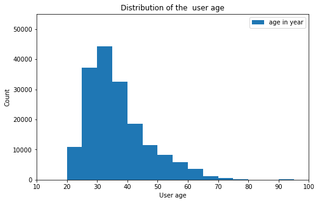

```python
#  plot the distribution of age .
binsize = 5
bins = np.arange(0, df['age'].max()+binsize, binsize)

plt.figure(figsize=[8, 5])
plt.hist(data = df, x = 'age', bins = bins , label= 'age in year')
plt.title('Distribution of the  user age')
plt.xlabel('User age')
plt.ylabel('Count')
plt.axis([10, 100, 0, 55000])
plt.legend()
```

> We can see the the above plot is right-screwed, with a long tail on the right.

> the most user age from 30 :35 years

### figure 2 : " what is the most user type ?"

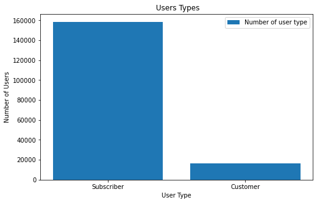

```python
# types of users on bar chart.
plt.figure(figsize=[8,5])
plt.bar(x = df.user_type.value_counts().keys(),label= 'Number of user type', height = df.user_type.value_counts() )
plt.xlabel('User Type')
plt.ylabel('Number of Users')
plt.title(' Users Types');
plt.legend()
```

> We can see the the above plot is subscriber is the most user type

### figure 3 : " what is the most gender ?"

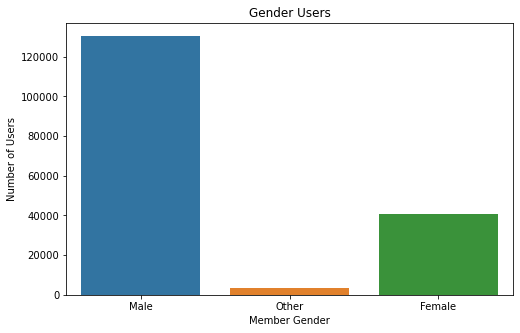

```python
# plotting genders on bar chart.
plt.figure(figsize=[8,5])
sb.countplot(data = df , x = 'member_gender' );
plt.xlabel('Member Gender');
plt.title('Gender Users');
plt.ylabel('Number of Users');
```

> We can see the the above plot is male is the most Gender

### figure 4 : " what is the most day of the week ?"

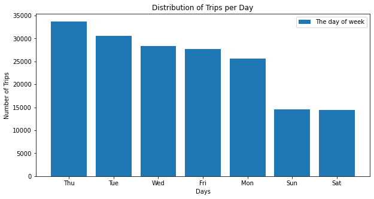

```python
#most day of the week
plt.figure(figsize=[10,5])
plt.bar(x = df.day.value_counts().keys(), height = df.day.value_counts(), label = 'The day of week')
plt.xlabel('Days')
plt.ylabel('Number of Trips')
plt.title('Distribution of Trips per Day')
plt.legend()
```

### Note

- clear from the above plot the thursday is most day of the week

## Bivariate Exploration

### figure 6 : " what the gender majorty users and majorty users type ?"

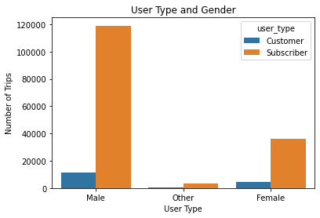

```python
# user types with the different genders
sb.countplot(data = df , x = 'member_gender', hue = 'user_type');
plt.xlabel('User Type');
plt.title('User Type and Gender');
plt.ylabel('Number of Trips');
```

### Note

1- The male gender is the majorty User in gender .

2-Subscriber user customer is majorty User in type User .

## Multivariate Exploration

### figure 7 : " what the most Day of the week for the users gender and users Types ?"

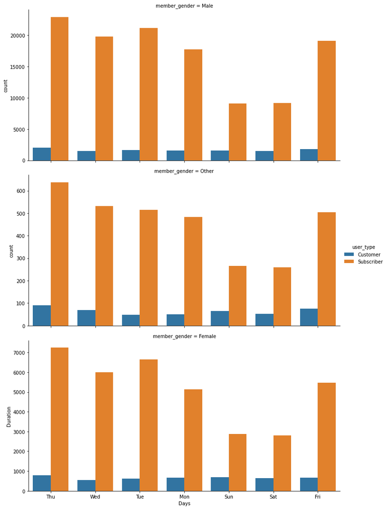

```python
#plotting the user types and gender to check how they relate to trip duration
sb.catplot(data=df,x='day',col='member_gender',
           hue='user_type', col_wrap = 1,
           height = 5, aspect=2,
           sharey=False, kind='count')
plt.xlabel('Days')
plt.ylabel('Duration')
```

### Note

1- the thursday is most day of the week of users genders and users types

### Talk about some of the relationships you observed in this part of the investigation. Were there features that strengthened each other in terms of looking at your feature(s) of interest?

> It is clear in above figure the male is the most than the female

### Were there any interesting or surprising interactions between features?

> But also the ratio of the female from the total female > the ratio of the male from total male